# Title

Methods in Ecology and Evolution Ecological modeling Plos PeerJ

## Title

`rbefdata` - leveraging access to data and semantics in ecological research projects

## Keywords

Data management, data sharing, data processing, paper proposals, biodiversity ecosystem functioning, semantic integration open source, open science

## Abstract

Point 1: set the context and purpose for the work; Point 2: indicate the approach and methods used; Point 3: outline the main results; Point 4: identify the conclusions, the wider implications and the relevance to management (max 350 words)

Over the last decade ecology has grown into a more collaborative and data intensive science in order to answer complex questions regarding our ecosystems. Fast developments in technical equipment and methodology for data acquisition allow researchers to gain almost real-time insights into various ecosystem variables. However a large amount of data in ecology traditionally is, and will be in future, collected manually by single researchers or small projects with experiments tailored to answer specific ecological questions. Emerging data management platforms and data sharing networks are of particular interest in ecology as they potentially allow to approach ecological questions in a synthetic way integrating various data sources to answer questions on a much broader temporal and spatial scale.

We here present the R package `rbefdata` as companion package to the ecological data management platform `BEFdata`. The package allows for the search of data, the access to data and metadata for analysis, as well as it offers upload functionality to either preserve new data or to update existing data. For the very first time the package tightly integrates the Ecological Metadata Language into R using attributes of data frames. It also allows to query a thesaurus which allows an enhanced search of datasets. We show how to use the `rbefdata` package with an example analysis that reconstructs one facet of an analysis about N-retention from the BEF-China experiment that has been published already.

The open source licensing of the data management platform as well as of the companion R package `rbefdata` allows even small ecological projects to run their own sophisticated data management and analysis setup. The integration of the Ecological Metadata Language into the portal and the R package enhance the analysis of data. Additionally the metadata ensures the data is prepared for reuse, the automatic import into workflow tools and the preservation of the valuable research data in case a project ends. Combining the rbefdata package with the data management portal significantly improves the data analysis workflow, the productivity and collaboration of any ecological project.

## Introduction

Introduction: State the reason for the work, the context and the hypotheses being tested.

- context of the work
  - many data is available
  - in ecology mostly small data
  - Small data is valuable data
  - small data is often not well described
  - We use meta data standards to provide users with information on data processing
- why do you developed rbefdata
  - To provide access to a data platform that is good in metadata and harmonization of data
- hypotheses tested
  - actually none because we do not test something.
  - rbefdata can significantly reduce the barrier to analyse ecological data stored on a befdata data management platform. we show this in a workflow.

Large amounts of ecological data are gathered each year by researchers worldwide to enhance the knowledge on our ecosystems. With a growing awareness on the value of data, various online data management platforms and metadata standards have been developed to preserve and provide access to a wide range of environmental data (cite e.g. diversity workbench, `BEFdata`, DataONE, LifeWatch, Pangea, Bexis, EML, ABCD). However there is still reluctance to use the platforms and the standards extensively as researchers fear to give away their data and describing data via metadata has no direct benefit.

In ecology the reuse of data is of particular interest as its integration offers the potential to answer questions on a much broader temporal and spatial scale (michener, 2008). Most of the data in ecology is collected in small and short term projects with their own design and methods they apply in order answer a few specific questions (e.g cite). Thus the data produced by these small projects often follows its own idiosyncratic structure that can be hard to understand, especially if no sufficient information about the study design, the applied methods or the codes used for abbreviations in datasets is provided (cite EML).

Unfortunately there are still some reasons many data is not well described and thus potentially lost for future generations of research.

However a problem with the reuse of data is, that available data is rarely well described.

Metadata is crucial here as plain primary research data can be hard to understand, and even hard to decipher by the authors themselves after some time has passed. For example it is hard to remember what methods have been used to collect the data of a certain column or what the abbreviations and the headers in the dataset mean. However metadata is still not used exhaustive as it usually means to put more time into the data with no direct benefit and to learn new tools that help to describe the data (e.g morpho, dataUP). Metadata gives researchers the opportunity to describe their data and others to understand raw research data even if they are not familiar with it (Fegraus 2005). The `BEFdata` portal allows an upload of metadata as spreadsheet and exports it to the EML metadata standard. The R package tightly integrates the metadata of datasets into attributes of R data frames.

Unfortunately there is no direct benefit of sharing data online that could motivate researchers to put more time into data that is required to prepare and upload it for sharing.

The `rbefata` R package provides upload functionality for datasets to the `BEFdata` portal for preservation. The `BEFdata` offers control over the access to uploaded data via a fine grained access rights system. Uploading data to the portal from within R sets the access rights to private which gives access to the owner only.

These platform provide data preservation for small scale projects as well as for large scale, big data producing, long term or remote sensing collaborations (cite e.g. diversity workbench, `BEFdata`, DataONE, LifeWatch, Pangea, Bexis). An ongoing trend in data preservation and accessibility is integrative data platforms that represent nodes (cite TRY, GBIF, Pangea) in a data network that collect data from smaller databases and enable researchers to access a wide range of data all from one place.

These platforms offer a solution to one of the most pressing general problems in data management, the loss of valuable data (Heidorn, 2008). Even tough these platforms improve the situation in data preservation, researchers are still reluctant to use them extensively as they fear to give away and loose the control over their data (michener 2012).

To find relevant data for reuse is a challenging task that is getting even more complex if more data gets available (Leinfelder et al, xxx). A common practice in data discovery, next to full text search in data and metadata, is the tagging with keywords (Nadrowski 2013). However a keyword search can be very coarse as the search for one specific keyword may cover a set of relevant data but misses other essential and relevant data tagged with close related or synonymous keywords (Leinfelder et al. xxx, michener 2008). For example an exact search for the keywords “weight” and “leaves” will likely miss datasets tagged with “dry weight”, “wet weight” or “plant organs”, that might be associated to datasets that are of interest as well. The integration of semantic repositories that provide taxonomies of terms can improve this. They embed the keywords from the search query into a hierarchical structure and so the query can be extended along known relations (Leinfelder et al.). Thus the `rbefdata` package offers functionality to access semantic repositories stored on `tematres` servers.

We here introduce the `rbefdata` R package as companion to the open source data management platform `BEFdata` (Nadrowski 2013). The package is part of the rOpenSci (http://ropensci.org/) initiative, a community driven project to provide the R statistics environment (R Development Core Team 2008) with a flexible access to scientific data repositories. The R package enables access to data and metadata stored on a `BEFdata` platform, integrates semantic repositories stored on `tematres` vocabulary servers (http://www.vocabularyserver.com/) and provides data preservation functionality for raw research data as well as for free format attachments files that are generated while analysing data with R. We showcase the functionality of the `rbefdata` package available with version 0.3.5. The R script we present shows the semantic refinement of keywords to improve the search of datasets, the use of metadata in data processing, how to access a complete set of data based on a paper proposal of the BEF-China experiment, and finally the upload of the data products. The R script shown here employs an analysis about N retention to showcase the package. The results of the analysis have been published already and the related data is open access (Lang et al. 2013). Thus the script shown here is fully reproducible.

## Material and Methods

• Include sufficient details for the work to be repeated.

### The BEF-China project

The BEF (Biodiversity Ecosystem Functioning) - China project, funded by the German Science Foundation (DFG, FOR 891) is a research collaboration consisting of 10-15 independent research groups (www.bef-china.de) with the overarching aim to disentangle the role of tree and shrub diversity for production, erosion control, element cycling, and species conservation in Chinese subtropical forest ecosystems. The project uses two main research platforms located in the provinces Jiangxi and Zhejiang in China (Bruelheide et al., 2012).

### The BEFdata platform

[BEFdata](http://befdataproduction.biow.uni-leipzig.de/) it the data management platform of the BEF-China project. It that has been developed within the project and it is is specialized in the management of small and heterogeneous data typical for ecology related research. It offers data preservation in a harmonized environment, fosters the exploration of data by a keyword tagging and search system and adheres to the Ecological Metadata Language standard standard for describing preserved data. The platform additionally facilitates research cooperations and discussions of ideas by a paper proposal tool. To create a paper proposal a researcher can select datasets from the platform to be included in an analysis. In the process of creating a proposal, basic information like a title, a rationale, the envisaged journal and a date needs to be provided. Submitting a proposal, a researcher asks data owner for access to the selected data and proposes his research idea to the project board and the data owners. The data owners can decide if they like to participate in the upcoming analysis or if they only like to get acknowledged for providing their data (Nadrowski 2013). This process allows to include or acknowledge all researchers involved in the data sampling process. Thus the paper proposals on the portal result in a direct benefit for providing data, they promote collaborations between research units and help to avoid duplication in publication initiatives on the same research ideas. Finally all datasets assembled in a paper proposal can be imported into the R environment using the `rbefdata` package.

### Usecase: N retention along a biodiversity gradient

[figure not shown]

- caption:  
  The paper proposal about the N retention analysis in its final approved state. The information on that page contains a title, a rational an envisaged date and the journal. The calculated authors and email lists for communication as well as the attached datasets and sub-projects involved (only partially shown). The results of the underlying analysis of the proposal are published already and thus for a detailed insight we refer to Lang et al. 2013.

### the `tematres` thesaurus

The `tematres` vocabulary server is an open source server software that offers features to manage, share and publish formal representations of knowledge. The `rbefdata` package can exploit vocabularies stored on a `tematres` vocabulary server. It can search for terms, display their descriptions as well as it can query the server for the relations of terms (broader, narrower). The `rbefdata` package by default connects to a `tematres` server instance with a thesaurus that, by the time of writing, contains round about 1000 terms which are related to ecology research. We used this default thesaurus to retrieve narrower keywords to show how the keyword based search for datasets can be improved.

## rbefdata

• Results: State the results, drawing attention to important details in tables and figures.

### Setup

The latest version of `rbefdata` can be directly installed from the CRAN repository. `rbefdata` offers a set of options that modify the behavior of the R package. The options can be set or queried via the `bef.options()` command. One of the most essential options is the user credentials. These are used to authenticate the user against the platform and to ensure weather the access to a specific datasets has been granted or not. Each user can find and change its credentials on his profile page on the `BEFdata` platform. The other options in the list represent the URLs to the `BEFdata` server instance and the `tematres` vocabulary server as well as a field that stores the name for a download folder. While the URL fields ensure the communication with the right servers, the download folder name is used to create a folder in case of a download of attached files from a dataset or paper proposal. The URL to the `BEFdata` and the `tematres` server default to the BEF-China project instances that are used in this paper to retrieve data from. If an own instance of either the `BEFdata` platform or the `tematres` vocabulary server has been set up, this URLs need to be changed accordingly, so the package communicates with the right servers (see box below).

```r
# list all options
bef.options()
```

```
## $url
## [1] "http://china.befdata.biow.uni-leipzig.de"
##
## $tematres_url
## [1] "http://tematres.befdata.biow.uni-leipzig.de/vocab/index.php"
##
## $tematres_service_url
## [1] "http://tematres.befdata.biow.uni-leipzig.de/vocab/services.php"
##
## $download_dir
## [1] "downloads"
##
## $user_credentials
## [1] ""
```

```r
# query a single option
bef.options("url")
```

```
## [1] "http://china.befdata.biow.uni-leipzig.de"
```

```r
# set credentials example
bef.options(user_credentials = "aölkjspoiul12")
```

```r
# set URL example
bef.options(url = "http://my.own.befdata.instance.com")
```

- Caption:  
  The `bef.options()` is used to set and query the options of the `rbefdata` package. The options determine the behavior of the package. All options can be shown at once to get an overview as well as one can pick a single options to display the value it is set to. The options can be set using the names of their fields like shown here for example the “user_credentials” and the “URL”.

### Discover Data

```
bef.tematres.api(task =
"fetchUp", "plant organ")
```

```r
# define the term plant organ
term_info = bef.tematres.api(task = "fetchNotes", "plant organ")
term_info
```

```
## $id
## [1] "446"
##
## $term
## [1] "plant organ"
##
## $language
## [1] "en"
##
## $description
## [1] "plant organ - a functional and structural unit of a plant"
```

```r
# get datasets tagged with plant organ
datasets_plant_organ = bef.get.datasets.for_keyword(c("plant organ", "weight"))
datasets_plant_organ
```

```
##     id
## 1  326
## 2  143
## 3  145
## 4  360
## 5  212
## 6  323
## 7  428
## 8  433
## 9  219
## 10 356
## 11 187
## 12 355
## 13 357
## 14 202
##                                                                                                   title
## 1                                            Tree functional identity weighted by abundance in the CSPs
## 2  Competition of tree saplings -Pilot- Biomass of target saplings - biomass allocation to constituents
## 3        Competition of tree saplings -Pilot- Biomass of target saplings - biomass allocation to strata
## 4                                                                          Detailed tree allometry data
## 5                      Leaf traits and chemicals from individual trees in the Gutianshan Nature Reserve
## 6                Leaf traits and chemicals from individual trees in the Main Experiment (Sites A and B)
## 7                                             Leaf traits and chemicals of 122 tree species in the CSPs
## 8                                               Seed addition experiment  Site A (VIPs) - biomass data
## 9                              Speficic leaf area (SLA) of Cunninghamia lanceolata and Pinus massoniana
## 10                      Stem disc data from undecomposed Schima superba used in the Ecoscape experiment
## 11                                                Traits of ferns and herb species occuring in the CSPs
## 12                                         Wood decomposition on the ESPs (VIPs and VIPREPs) first year
## 13                                                Biomass Allometry Equations of Pilot Experiment (SP7)
## 14   Carbon (C) and Nitrogen (N) Concentration (Root, Stem, Twig, Leaf) of 8 target species in the CSPs
```

```r
# narrow down plant organ
narrow_tasks_plant_organ = bef.tematres.api(task = "fetchDown", "plant organ")
narrow_tasks_plant_organ
```

```
## $id
## [1] "456" "447" "449" "450" "451" "454" "457"
##
## $term
## [1] "branch"        "flower"        "fruit"         "inflorescence" "leaf"
## [6] "seed"          "twig"
```

```r
# enrich the search with narrower keywords
datasets_plant_organ_narrow = bef.get.datasets.for_keyword(c(narrow_tasks_plant_organ$term, "weigth"))
```

[output not shown]

[output not shown]

```r
# get an indea what is in the response
head(datasets_plant_organ_narrow)
```

[output not shown]

```r
dim(datasets_plant_organ_narrow)
```

[output not shown]

- caption:  
  The code box shows the use of the default `tematres` thesaurus used by the `rbefdata` package to improve the search of datasets on a `BEFdata` platform. Terms can be defined, narrowed or broadened to extend the search query for datasets against the `BEFdata` portal with the `bef.get.datasets.for_keyord()` command.

### Download data

```r
# the proposal URL shows the id is 90 http://china.befdata.biow.uni-leipzig.de/paperproposals/90
# http://china.befdata.biow.uni-leipzig.de/datasets/

# get datasets
datasets = bef.get.datasets.for_proposal(id = 90)

# extract second dataset
extract_second_dataset = datasets[[2]]

# show the first lines of the second dataset
head(extract_second_dataset, 5)
```

```
##     plot_id recov_plot perleaf_plot perroot_plot perbio_plot persoil_plot gbd_T0.mm.
## 1 pilot1D01     15.642        2.918       1.0015       3.920        96.08         NA
## 2 pilot1D02     13.032        5.523       1.3688       6.891        93.11      3.688
## 3 pilot1D04     20.292        1.057       0.5157       1.572        98.43      2.875
## 4 pilot1D05      9.595        4.187       1.0861       2.032        97.97      6.000
## 5 pilot1D07      8.354       15.100       5.0983      17.963        82.04      7.000
```

- caption:  
  The code box shows how to find the ID of the paper proposal and how to download the associated data into the R environment. As example the second dataset is extracted from the list that keeps the three datasets of the proposal and the first few lines of the dataset are displayed.

### Inspect data

```r
# the URL of the dataset, ID (335) http://china.befdata.biow.uni-leipzig.de/datasets/335

# get metadata by dataset ID
bef.portal.get.metadata(dataset = 335)$title
```

```
## [1] "Competition of saplings for N -Pilot- system 15N retention"
```

```r
# extract title of first dataset in proposal
attributes(datasets[[1]])$title
```

```
## [1] "Competition of saplings for N -Pilot- 15N recovery in leaves and fine roots "
```

```r
# extract all dataset titles in the proposal
titles = sapply(datasets, function(x) attributes(x)$title)
titles
```

```
## [1] "Competition of saplings for N -Pilot- 15N recovery in leaves and fine roots "
## [2] "Competition of saplings for N -Pilot- system 15N retention"
## [3] "Plottreatment and -location within the blocks of the Pilot-Experiment"
```

```r
# other metadata available
names(attributes(datasets[[1]]))
```

```
##  [1] "names"                    "class"                    "row.names"
##  [4] "title"                    "abstract"                 "publicationDate"
##  [7] "language"                 "creators"                 "authors"
## [10] "intellectualRights"       "distribution"             "keywords"
## [13] "generalTaxonomicCoverage" "samplingDescription"      "spatial_coverage"
## [16] "temporal_coverage"        "related_material"         "columns"
```

- caption:  
  The code box shows the two possible ways of getting metadata information for dataset provided on a BEFdata platform. First the meta data can be directly accessed by the `bef.portal.get.metadata()` command that needs the ID of dataset for download. The ID can be obtained from the URL of the dataset. As each dataset is associated with metadata on download it can be extracted by the R internal `attributes()` command.

The dataset list from the proposal contains three datasets, of which we only use the second and third here. These two are written into two separate R variables called `Nretention` and `design` before merging them. Inspecting the headers of both datasets reveals that each of them contains a column with a `plot_id` that seems suitable for merging. We make use of the metadata of the columns to check if this really is the case.

```r
# extract into separate datasets
Nretention = datasets[[2]]
design = datasets[[3]]

# overview about the contents of the datasets

# names in dataset Nretention
names(Nretention)
```

```
## [1] "plot_id"      "recov_plot"   "perleaf_plot" "perroot_plot" "perbio_plot"  "persoil_plot"
## [7] "gbd_T0.mm."
```

```r
# description of column plot_id
Nretention_column_plot_id_description = attributes(Nretention)$columns[1, ]$description
Nretention_column_plot_id_description
```

```
## [1] "Reasearch plots of the Biodiversity - Ecosystem functioning experiment (BEF-China). There are three main sites for research plots in the BEF Experiment: Comparative Study Plots (CSP) in the  Gutianshan Nature Reserve, having a size of 30x30m^2, measured on the ground. Main Experiment plots h…
```

```r
# names in dataset Nretention
names(design)
```

```
##  [1] "block"                    "x"                        "y"
##  [4] "plot_id"                  "control_ID"               "block_community_code"
##  [7] "community_number"         "species_mixture"          "species_diversity"
## [10] "species_pool"             "species_code"             "research_group_colour"
## [13] "control"                  "closed_canopy"            "density"
## [16] "Natives"                  "depth"                    "harvest"
## [19] "fungicide"                "inoculation"              "pesticide"
## [22] "native"                   "genetic_diverstiy"        "seed_addition"
## [25] "fertilizer"               "plot_treatment_connected" "sp1"
## [28] "sp2"                      "sp3"                      "sp4"
## [31] "sp5"                      "sp7"                      "sp8"
## [34] "sp11"                     "sp_connected"
```

```r
design_column_plot_id_description = attributes(design)$columns[4, ]$description
design_column_plot_id_description
```

```
## [1] "Reasearch plots of the Biodiversity - Ecosystem functioning experiment (BEF-China). There are three main sites for research plots in the BEF Experiment: Comparative Study Plots (CSP) in the  Gutianshan Nature Reserve, having a size of 30x30m^2, measured on the ground. Main Experiment plots h…
```

```r
# the synthesis dataset
syndata = merge(Nretention, design)
```

- caption: The second and the third dataset from the proposal are written into separate variables. The metadata is used to ensure the merge ids contain appropriate values for merging.

### Analyse data

After merging the two datasets into a new synthesis dataset the data frame still contains many columns that are not required for the analysis and thus can be dropped. To analyse system N retention we need information about the species diversity in the plots and about which plot is placed in which block from the design dataset. 'Species diversity' is used as a factor containing three levels (1,2,4 species mixtures). The response variables have been checked for normality with `qqplot` and transformed as shown in the box below.

```r
# overview about the content of the synthesis dataset
names(syndata)
```

```
##  [1] "plot_id"                  "recov_plot"               "perleaf_plot"
##  [4] "perroot_plot"             "perbio_plot"              "persoil_plot"
##  [7] "gbd_T0.mm."               "block"                    "x"
## [10] "y"                        "control_ID"               "block_community_code"
## [13] "community_number"         "species_mixture"          "species_diversity"
## [16] "species_pool"             "species_code"             "research_group_colour"
## [19] "control"                  "closed_canopy"            "density"
## [22] "Natives"                  "depth"                    "harvest"
## [25] "fungicide"                "inoculation"              "pesticide"
## [28] "native"                   "genetic_diverstiy"        "seed_addition"
## [31] "fertilizer"               "plot_treatment_connected" "sp1"
## [34] "sp2"                      "sp3"                      "sp4"
## [37] "sp5"                      "sp7"                      "sp8"
## [40] "sp11"                     "sp_connected"
```

```r
# remove unused variables from synthesis dataset
syndata = syndata[-c(9:14, 16:41)]
names(syndata)
```

```
## [1] "plot_id"           "recov_plot"        "perleaf_plot"      "perroot_plot"
## [5] "perbio_plot"       "persoil_plot"      "gbd_T0.mm."        "block"
## [9] "species_diversity"
```

```r
# > we want to use 'species_diversity' as a factor
syndata$species_diversity = as.factor(syndata$species_diversity)

# square root transform response variables
syndata$recov_plot_t = syndata$recov_plot^0.5
syndata$perleaf_plot_t = syndata$perleaf_plot^0.5
syndata$perroot_plot_t = syndata$perroot_plot^0.5
syndata$persoil_plot_t = syndata$persoil_plot^0.5
```

The data was analysed by linear mixed effects models. Since the plots are nested in blocks, the block was used as a random factor. The analysis uses the R packages `nlme` (Pinheiro et al. 2013) for modeling and `multcomp` (Hothorn et al. 2008) for post-hoc comparisons. To adjust for an unbalanced experimental design an ANOVA Type II was carried out to test for main effects using the R package `car` (Fox and Weisberg 2011). The models have been evaluated visually.

```r
require(nlme)
require(multcomp)
require(car)
```

```r
### Model 1: Overall recovery/N retention
model1 = lme(recov_plot_t ~ gbd_T0.mm. + species_diversity, syndata, random = ~1 | block, na.action = na.omit,
    method = "REML")
anova(model1)
```

```
##                   numDF denDF F-value p-value
## (Intercept)           1    34   870.6  <.0001
## gbd_T0.mm.            1    34     7.5  0.0098
## species_diversity     2    34     2.9  0.0714
```

```r
summary(glht(model1, linfct = mcp(species_diversity = "Tukey")))
```

```
##
##   Simultaneous Tests for General Linear Hypotheses
##
## Multiple Comparisons of Means: Tukey Contrasts
##
##
## Fit: lme.formula(fixed = recov_plot_t ~ gbd_T0.mm. + species_diversity,
##     data = syndata, random = ~1 | block, method = "REML", na.action = na.omit)
##
## Linear Hypotheses:
##            Estimate Std. Error z value Pr(>|z|)
## 2 - 1 == 0   -0.378      0.251   -1.51    0.280
## 4 - 1 == 0    0.478      0.420    1.14    0.482
## 4 - 2 == 0    0.857      0.399    2.15    0.077 .
## ---
## Signif. codes:  0 '***' 0.001 '**' 0.01 '*' 0.05 '.' 0.1 ' ' 1
## (Adjusted p values reported -- single-step method)
```

```r
# ANOVA type II test for unbalanced design
model1c = Anova(model1, type = "II")
model1c
```

```
## Analysis of Deviance Table (Type II tests)
##
## Response: recov_plot_t
##                   Chisq Df Pr(>Chisq)
## gbd_T0.mm.         7.42  1     0.0064 **
## species_diversity  5.71  2     0.0576 .
## ---
## Signif. codes:  0 '***' 0.001 '**' 0.01 '*' 0.05 '.' 0.1 ' ' 1
```

```r
### model evaluation checking plots to assess whether residuals are well behaved plot(model1)
### whether the response variable is a reasonable linear function of the fitted values
### plot(model1,recov_plot_t~fitted(.)) and whether the errors are reasonably close to normal
### distribution in all four blocks (Crawley 2009) qqnorm(model1,~resid(.)|block)

## Model2 percentage leaf recovery of plot recovery
model2 = lme(perleaf_plot_t ~ species_diversity, syndata, random = ~1 | block, method = "REML")
anova(model2)
```

```
##                   numDF denDF F-value p-value
## (Intercept)           1    36  273.06  <.0001
## species_diversity     2    36    6.56  0.0037
```

```r
summary(glht(model2, linfct = mcp(species_diversity = "Tukey")))
```

```
##
##   Simultaneous Tests for General Linear Hypotheses
##
## Multiple Comparisons of Means: Tukey Contrasts
##
##
## Fit: lme.formula(fixed = perleaf_plot_t ~ species_diversity, data = syndata,
##     random = ~1 | block, method = "REML")
##
## Linear Hypotheses:
##            Estimate Std. Error z value Pr(>|z|)
## 2 - 1 == 0    1.053      0.293    3.59   <0.001 ***
## 4 - 1 == 0    0.865      0.497    1.74     0.18
## 4 - 2 == 0   -0.188      0.479   -0.39     0.92
## ---
## Signif. codes:  0 '***' 0.001 '**' 0.01 '*' 0.05 '.' 0.1 ' ' 1
## (Adjusted p values reported -- single-step method)
```

```r
Anova(model2, type = "II")
```

```
## Analysis of Deviance Table (Type II tests)
##
## Response: perleaf_plot_t
##                   Chisq Df Pr(>Chisq)
## species_diversity  13.1  2     0.0014 **
## ---
## Signif. codes:  0 '***' 0.001 '**' 0.01 '*' 0.05 '.' 0.1 ' ' 1
```

```r
# model evaluation plot(model2) plot(model2,recov_plot_t~fitted(.))
# qqnorm(model2,~resid(.)|block)

## Model3 percentage root recovery of overall recovery
model3 = lme(perroot_plot_t ~ species_diversity, syndata, random = ~1 | block, method = "REML")
anova(model3)
```

```
##                   numDF denDF F-value p-value
## (Intercept)           1    36   374.2  <.0001
## species_diversity     2    36     7.2  0.0024
```

```r
summary(glht(model3, linfct = mcp(species_diversity = "Tukey")))
```

```
##
##   Simultaneous Tests for General Linear Hypotheses
##
## Multiple Comparisons of Means: Tukey Contrasts
##
##
## Fit: lme.formula(fixed = perroot_plot_t ~ species_diversity, data = syndata,
##     random = ~1 | block, method = "REML")
##
## Linear Hypotheses:
##            Estimate Std. Error z value Pr(>|z|)
## 2 - 1 == 0    0.601      0.170    3.53   0.0013 **
## 4 - 1 == 0    0.733      0.288    2.54   0.0281 *
## 4 - 2 == 0    0.132      0.278    0.48   0.8792
## ---
## Signif. codes:  0 '***' 0.001 '**' 0.01 '*' 0.05 '.' 0.1 ' ' 1
## (Adjusted p values reported -- single-step method)
```

```r
Anova(model3, type = "II")
```

```
## Analysis of Deviance Table (Type II tests)
##
## Response: perroot_plot_t
##                   Chisq Df Pr(>Chisq)
## species_diversity  14.3  2    0.00077 ***
## ---
## Signif. codes:  0 '***' 0.001 '**' 0.01 '*' 0.05 '.' 0.1 ' ' 1
```

```r
# model evaluation plot(model3) plot(model3,recov_plot_t~fitted(.))
# qqnorm(model3,~resid(.)|block)

## Model 4 percentage soil recovery of overall recovery
model4 = lme(persoil_plot_t ~ species_diversity, syndata, random = ~1 | block, method = "REML")
anova(model4)
```

```
##                   numDF denDF F-value p-value
## (Intercept)           1    36   26248  <.0001
## species_diversity     2    36       4  0.0274
```

```r
summary(glht(model4, linfct = mcp(species_diversity = "Tukey")))
```

```
##
##   Simultaneous Tests for General Linear Hypotheses
##
## Multiple Comparisons of Means: Tukey Contrasts
##
##
## Fit: lme.formula(fixed = persoil_plot_t ~ species_diversity, data = syndata,
##     random = ~1 | block, method = "REML")
##
## Linear Hypotheses:
##            Estimate Std. Error z value Pr(>|z|)
## 2 - 1 == 0   -0.294      0.127   -2.32     0.05 *
## 4 - 1 == 0   -0.499      0.215   -2.33     0.05 *
## 4 - 2 == 0   -0.205      0.207   -0.99     0.57
## ---
## Signif. codes:  0 '***' 0.001 '**' 0.01 '*' 0.05 '.' 0.1 ' ' 1
## (Adjusted p values reported -- single-step method)
```

```r
Anova(model4, type = "II")
```

```
## Analysis of Deviance Table (Type II tests)
##
## Response: persoil_plot_t
##                   Chisq Df Pr(>Chisq)
## species_diversity  7.96  2      0.019 *
## ---
## Signif. codes:  0 '***' 0.001 '**' 0.01 '*' 0.05 '.' 0.1 ' ' 1
```

```r
# model evalution plot(model4) plot(model4,recov_plot_t~fitted(.))
# qqnorm(model4,~resid(.)|block)
```

### Results of the N retention analysis

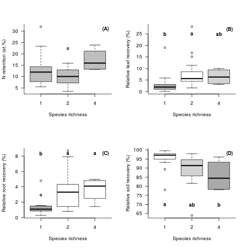

- caption: Nitrogen (N) retention affected by species richness. N retention summed as the recovery of soil, roots and leaves (a), relative leaf recovery (b), relative root recovery © and relative soil recovery (d). Significant differences as revealed by post hoc Tukey’s test (P < 0.05) are indicated by different letters.

### Upload data

Finally we need to decide on either to upload a full dataset which could be done using the dataset upload function `bef.portal.upload.dataset()` or only to upload the script and maybe a figure to highlight the road to the results from the source datasets used. The second of which could be done by attaching to the proposal with the command `bef.portal.attach.to_proposal()`. For the analysis shown here, it is the best way to go with an attachment to the proposal as uploading the merged dataset would only mean duplication of data in the database of the `BEFdata` portal we upload to. So we upload the script and the four pane figure with its caption to add them to the proposal. The figure is prepared as Portable Network Graphics (PNG) using the R internal PNG device. It is written to a temporary folder and then uploaded. The script in this case is an R markdown file that we attach to the proposal (see box below).

```r
# attach the script using a path
bef.portal.attach.to_proposal(id = 90, attachment = "./rbefdata.Rmd", description = "The R script that has been used to derive the results in the published paper")
```

```
## [1] "Attachment to proposal with ID: 90 successful!"
```

- caption:  
  The script is attached to the proposal using the `bef.portal.attach.to_proposal()` command. It takes the id of the proposal, the file attachment, where we give a path to the location of the file, and a description as parameters.
- caption:  
  The plots are prepared and put together into a single four pane graphic. The plots are exported to hard drive using the R built-in Portable Networks Graphics (PNG) device.

```r
# caption of the figure
caption = "Nitrogen (N) retention affected by species richness. N retention summed as\n           the recovery of soil, roots and leaves (a), relative leaf recovery (b), relative root\n           recovery (c) and relative soil recovery (d). Significant differences as revealed by post\n           hoc Tukey’s test (P < 0.05) are indicated by different letters."

# upload the figure
bef.portal.attach.to_proposal(id = 90, attachment = file.path(tempdir(), "results_plot_proposal_90.png"),
    description = caption)
```

```
## [1] "Attachment to proposal with ID: 90 successful!"
```

- caption: A description of the figure is written into a variable and the `rbefdata` command to attach to a proposal is used again to upload the exported four pane graphic to the proposal.

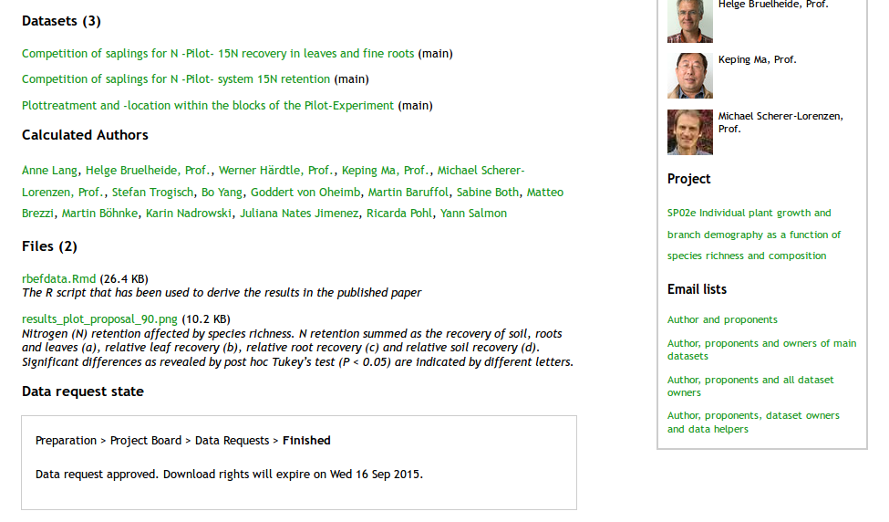

- caption: The paper proposal in its final approved state with attachments. The attachments are the final results four pane figure and the R script that has been used to derive the results in the published paper.

## Discussion

• Discussion: Point out the importance of the results and place them in the context of previous studies and in relation to the application of the work (expanding on the Synthesis and applications section of the Summary). Where appropriate, set out recommendations for management or policy.

- structure of intro
  - many data
  - reuse
  - metadata
  - data search
  - preprocessing with semantics integrated
  - wrapup (metadata/paper proposals/workflows)
- potential structure of discussion?
  - Data life cycle
  - Data preservation
  - Metadata
  - Data exploration/processing
  - Metadata
  - Semantics
  - Taxonomies
  - BEFdata and rbefdata solutions

Even though the situation with preserving data has been improved by online data management platforms (data warehouses), there is still many valuable data lost (long tail). In ecology this is related to the overall heterogeneic nature of the research domain and to the fact that data is collected mostly by small and short term research projects spread all over the world. Many of these projects lack a data management plan that would ensure the preservation and preparation of data for sharing and resuse. Additionally researchers are still reluctant to use online data management on their own initiative. They fear to give away and loose the control over their data and ideas. Another hurdle to online data preservation and sharing is a lack of benefit for data providers. The preparation of data for this porpose only means more effort without any further outcome. The open source data mangement platform BEFdata offers a sophisticated online data management platform for ecological projects. It covers requirements like the preservation of data and offers a metadata description tool for data that helps to prepare data for the long term preservation and reuse. Due to its open source character and simplicity each project can set up its own instance of the platform to directly benefit from online data management, without giving data away. If a project ends, the BEFdata portal also offers a simple exti strategy as it sticks to metadata standars (EML) that make importing the datasets into other platforms simple.

The software combination `rbefdata` and `BEFdata` provides solutions to many of these aspects of data management like data preservation, online data sharing and discussion of ideas, data processing, intensive use of meta data and the preservation of workflows used to derive results which is important for reproducibility and provenance that in turn is again a crucial component to provide effective incentives in form of acknowledgements for data providers.

The `BEFdata` platform serves as a scratch pad for research data as well as it covers the preservation of data. It offers data harmonization tools, metadata support via the Ecological Metadata Language standard and a social component that fosters sharing data online (cite Karin). The `rbefdata` package enables access to the data and metadata on the platform as well as it provides upload functionality right from within the R environment

The availability of a broad range of data and useful metadata is essential to many steps in the life cycle of data starting from exploration over the integration to processing and the effective reuse of data.

In ecology the integration of available data offers the potential to answer some of the most pressing global relevant questions like for example about the global climate change and the maintainability of vital ecosystem services.

- BEFdata and rbefdata solutions
  - set incentives for data preservation
  - acknowledgement
  - contribution to upcoming papers
  - data publishing (citable)
  - use common tools transfer to metadata standards
  - metadata from spreadsheets to EML
  - reproducibility
  - preservation of scripts as attachments to proposals/datasets

This requires efficient tools that not only help to access the data but also to process it and to preserve data products and results including how they have been derived to be fully reproducible as scripts or workflows

less effort has been put into preservation of algorithms and workflows that researchers use to derive their data products and results.

One one hand there is many data already available. And on the other hand many data is still lost.

This requires the reuse and integration of mostly small and heterogeneous data.

Even though the situation gets better there is still many data lost as researchers are reluctant to use online data preservation tools as they fear to loose the control over their data.

Collaboration.

While well described data helps a lot in understanding datasets and on deciding upon the relevance and applicability of data for a certain analysis there is still lots of manual intervention necessary to prepare the data for analysis (cite Karin and me? or xxx). It may needs to be cleaned, imputed, reshaped and merged which usually takes up to 70% of an analysis workflow, before smart models can be applied to the data to find interesting patters (cite the workflow paper of Karin and me). This preparatory steps not only are time and labour intensive but also potentially error prone, especially as the complexity of the analyses increases. Provenance and the advantage of keeping scripts (workflows) close to the data.

In ecology the reuse of the mostly small and heterogeneous data seems promising. It can be integrated into a wider context to answer questions on a much broader, temporal and spatial scale.

This is of particular intrest in terms of the most pressing questions in ecology

There is a growing demand to reuse available data and for tools that enable researchers to deal with requirements like data preservation, exploration and reuse as well as with the description process of data via meta data.

However, particularly research areas like ecology which are characterised by a high degree of interdisciplinary interactions are challenging in terms of data management and the applicability of some valuable concepts like ontologies seems questionable. While ontologies with a very clear and close scope are in use already (onto verse examples) the development of a sophisticated ontology for ecology research is a very time, labor intensive and complex task. The nature of ecology requires a community for the development of ontologies that includes experts from all contributing domains to model the relevant concepts into a formal representation.

(supporting, Kepler).

`rbefdata` makes scripting a workflow to pull data for analysis and push back results and scripts simple. The upload mechanism can help to keep the data management platform up to date and gives other researchers the possibility to reproduce results by downloading scripts attached to proposals or datasets. An uploaded script is not only a stepping stone to reproducible research but also helps to track down data provenance which can be interesting in terms of acknowledgement for data providers in a more fine grained view.

While it seems a waste of time and bandwidth on one hand to always transfer the data to a local script for processing, this approach also has its upsides. Having the data locally offers full flexibility in choice of tools and also enables the researcher to freely mix in other local data sources. While this approach works well for small data it does not for big data since the transfer of data is not possible for large sized data. The recent trend here is on-server/in-database statistics, a scenario where scripts are to be sent to the server before it returns the answer after processing (xxx). To keep the `BEFdata` platform as flexible as possible and to give the researchers the freedom of choice this could be one of the future features to be integrated.

### rbefdata makes metadata available within the R environment

`rbefdata` is innovative in that it provides data together with metadata in the R environment.

### keeping workflow scripts close to the data: Provenance

Clarify: controlled vocabulary - thesaurus - ontology. Controlled vocabulary for finding and sorting, ontology for automatic reasoning.

- Semantics for searching and sorting

We decided not to develop functionality to develop nested controlled vocabularies within BEFdata. This decision was based on the fact that there are already sophisticated frameworks and software to develop and maintain vocabularies. Linking to external vocabularies has the additional advantage that several data repositories can simultaneously use the same thesaurus for tagging their data. This keeps single repositories small and coherent without loosing the potential to link them to other repositories (linked data, citations for linked data).

- Semantics for automated reasoning

This is a separate argument, and we do not touch it in the results: automatic merging should be only in the discussion:

Additionally it can be error prone especially if analyses get more complex and require the expertise of more than one research domain.

Ontologies, as formal representations of knowledge, potentially offer a sophisticated tool to deal with that step of data preparation (e.g michener et al 2012). While they are already used in some research domains like genetics (cite xxx, eg. http://www.geneontology.org/), other domains face more problems using it (cite xxx, morpho team announced semantic tagging but the plug-in did not appear anywhere). The application of ontologies in ecology is discussed controversially (cite xxx) and it is argued that they can be a huge benefit, but it is hard to set up a sophisticated ontology covering all necessary terms and relation of a highly complex research domain (cite xxx).

We recently started to develop an ontology using a `tematres` .The formalization we develop will be based on the knowledge used in biodiversity ecosystem functioning research.

The `BEFdata` platform will get a semantical tagging feature that will allow data owners to tag data fine granular ?? on data column level. Using the same formalized knowledge from the ontology we will be able to provide smart merging and transformation features within the `rbefdata` package that help researchers to merge datasets semi automatic.

While data storage and description is almost the same for all kind of data the effective interlinking of data via an ontology requires the development of a common terminology. The terminology should not only be accepted but used, developped and discussed by all contributing scientist of the project. The future goal on ontologies is of course the development of domain ontologies that can be interlinked to an overarching ontology. Thus, collaborative ontology engineering approaches like `ontoverse` (Zoulfa El Jerroudi et al. 2008) or `tematres` are highly valuable as they not only help to set up ontologies but also to develop and maintain them over time even if the researchers change that contribute to it.

## Acknowledgements

Thanks to all the data owners of the proposal for providing access to the datasets. …

## Literature

This will be done externally as markdown has no good way to deal with references and stuff. We can collect here a list of links to references. I will then collect them with e.g zotero to export a format we can hand them in for publication.

## Appendix

### saveaway

Lost a high amount of valuable data as researchers are still reluctant to give away their data. One possible solution to this would be to make data preservation obligatory and make it a condition for sponsorship of projects.

This highlight a way on how the integration of semantic repositories can enhance the process of data exploration on a `BEFdata` portal.

The package enables access to data and metadata stored on the platform as well as it the dataset exploration by the integration of an online thesaurus.

It tightly integrates the metadata into R data frames so it can be accessed directly when processing data from the portal. `rbefdata` includes an access to an online thesaurus that can be used to improve the discovery of datasets stored on the portal. Furthermore it provides upload functionality so any data product can be pushed directly back to the data portal for preservation. We integrate data management concepts like a semantic improved exploration of datasets, a seamless access to data and metadata and the preservation of data products directly into the R environment.

The `BEFdata` platform offers a keyword based search for datasets that is made available from within the `rbefdata` package as well by the `bef.get.datasets.for_keyword()` command. Thus we can use the vocabulary integration to enhance the exploration of datasets along the relations provided by the vocabulary server.

Today ecologists have access to a huge amount of environmental and historic data. This puts much pressure on the development of tools that enable researchers to explore, process, reuse as well as to preserve derived data products and their provenance traces. Although there are many tools and concepts available already in data management that provide features that cover almost the whole life cycle of data, only a few of them are widely spread or accepted throughout ecology. This is related to different reasons like for example a lack of benefit for researchers to prepare and share data online and the fear to give away and loose the control over the data. However there are still many small projects in ecology that do not have a sophisticated data management at all and many data simply get lots over time.

The preparation of datasets for long term preservation and online sharing is time intensive and in most cases involves the learning of new tools that support the process. Thus the tight integration integration of data management concepts into widely used software tools like for example the R statistics environment.

This situation can be improved by the tight integration of data management concepts into existing and widely used software and thus into the daily workflow of researchers but also through concepts that help researchers gain trust in online data management platforms. Paper proposals and data provenance as a way to promote collaborations by the discussion of ideas and, metadata to improve data preservation and information exchange as well as the integration of semantic resources to enhance data exploration and processing, only represent a few examples of concepts with the potential to improve the progress of a data intensive scientific domain like ecology. The `rbefdata` R package together with the data management platform `BEFdata` combine the strengths of the data management concepts mentioned into a sophisticated data management software package that makes use of widely accepted tools in ecology.

The use and reuse of available data is promising as the integration offers the opportunity to answer questions on broad temporal and spatial scale.

Before data can effectively be reused it may need to be cleaned, imputed, reshaped and merged which usually takes up to 70% of an analysis (Garijo 2012, Pfaff 2013 in prep). These preparatory steps are not only time and labour intensive but also potentially error prone, especially if the amount and complexity of data to be included increases. The integration of ontologies can help to solve these problems (michener 2008). As ontologies allow the machine readable access to knowledge of a scientific domain they can be used to develop tools that “understand” the contents of datasets and guide researchers on the process of data preparation. While ontologies with a narrow and clear scope are very well used already (cite xxx, e.g gene Ontology) it is a challenging tasks to create an ontology for research domains like ecology that are characterized by a high degree of interdisciplinary interactions (Parsons 2011). This characteristic leads to a heterogeneous landscape of knowledge and concepts that would need to be covered and formalized by the ontology.

We discuss `rbefdata` and `BEFdata` in in the light of current and future challenges for data management give an outlook onto upcoming features that could help to solve them.

The data here is mainly provided by small scale studies spread all over the world (e.g heidorn2009 shedding light on the dark) but also through bigger long term projects like LTER (cite xxx), BEF-China (cite xxx), governmental projects and local initiatives (cite xxx) and private persons. This in fact results in a wild growing, complex and heterogeneous data landscape that an ontology would need to capture to be usable.

### intro karin

Karin:

thesauri, ontologies, etc. …

Introducing workflows, their merits, and ROpenSci. But also Kepler, Pegasus, etc. Cite our paper on workflows.

(http://ropensci.org/), which is a community driven approach to wrap all science APIs and to create solutions for R users to seamlessly pull data from different repositories spread over the internet into R for analysis.

### material and methods

Karin:

- I would suggest to reduce the details of the following dramatically:

The Main experiment was established in 2009 and 2010 as the first large scale forest biodiversity–ecosystem functioning experiment in the highly species-rich subtropics. In total, the area covers 50 ha and there are 566 plots of 400 trees each, ranging in diversity from monoculture to 24-species mixtures. The experiment used 42 native tree species and 10 shrub species, combined into different species pools. More than 400 000 tree and shrub saplings were planted. In a parallel observational approach, a total of 27 Comparative Study Plots (CSPs) of 30x30 m each were set up in existing forests in the adjacent Gutianshan National Nature Reserve (Zhejiang Province) in 2008. The observational plots were selected according to a crossed sampling design along tree species richness and stand age. The CSPs address the impact of successional age on ecosystem functioning, providing a basis for assessing the successional processes at work across tree species diversity in the Main Experiment .

### Data processing and integration

- sharing ideas for analysis: paper proposals Paper proposals are an emerging concept solving transparant data exchange and reuse across disciplines and laboratories [citations!]
- Introducing workflows (merits, ROpenSci, Kepler, Pegasus, etc.) Cite our paper on workflows.
- Workflow repositories and software
- R needs to be learned as well that is no argument to less acceptance of other tools like Kepler, is there?!
- Provenance and the advantage of keeping scripts (workflows) close to the data.

### Wrap up (introduce solutions)

Especially for highly interdisciplinary research domains this requires the input of many scientists and discussions about definitions and relations of terms in the representation. This might be one of the reasons why there is a lack of sophisticated ontologies especially for highly interdisciplinary research domains like ecology.

Karin: there are some papers talking about what users want from data repositories. These could be cited (e.g. Kerstin Bach). Motivate that researchers prefer to perform the analyses at their own laptops.

While data preservation and the access to data for a wider audience are covered very well, the use of metadata and semantic concepts, which both are related to the efficient reuse of data lacks behind. On one hand this is related to the reluctance of users to use new tools or the fear to loose control over valuable data. But on the other hand this is also related to the fact that the valuable concepts are not yet tightly integrated enough into the researchers daily workflow.

- intro summary frame

A multitude of data management and knowledge platforms are emerging which contribute to a growing global data pool. The need to effectively reuse the available data, grows with the data pool. This puts much pressure on the development of tools that tightly integrate valuable concepts into existing and widely accepted tools and into the workflows of researchers to help them dealing with the upcoming challenges in data management and analysis.

- data preservation -> many data available